# Asset pricing anomalies

This is the companion notebook to the course on empirical **foundations** of machine learning in asset management.  
The topic is strongly tilted towards **asset pricing anomalies** and serves as the economic justification of ML-based factor portfolios. Indeed, since the 1990s, a large body of empirical work has shown that firms’ characteristics have an impact on future returns. This impact is possibly **time-varying**.  
The first chunks of the code are inspired from the book **Reproducible Finance** by Jonathan Regenstein.  
The code is commented and the results are discussed as much as possible.

$\rightarrow$ **ABOUT THE NOTEBOOK**:

- the code chunks are **sequential**. They must be executed in the correct order.
- text between **stars** appears in bold in html format.

# 1 Data collection

First, we collect the data for our baseline assets. We work with 6 large American companies which are associated to their ticker symbol: **Apple** (AAPL, technologies), **Boeing** (BA, industry), **Citigroup** (C, banking), **Pfizer** (PFE, healthcare), **Walmart** (WMT, retail) and **Exxon** (XOM, oil/commodities). The six firms have been chosen in very diverse industry sectors.

**NOTE:** The analysis below should be carried out on a much larger number of assets. We restrict the width of the analysis for simplicity and for computational purposes.

```r
if(!require(tidyverse)){install.packages("tidyverse")}
if(!require(quantmod)){install.packages("quantmod")}
if(!require(lubridate)){install.packages("lubridate")}
library(tidyverse)          # Package for data manipulation
library(quantmod)           # Package for data extraction
library(lubridate)          # Package for date management
tickers <- c("AAPL", "BA", "C", "PFE", "WMT", "XOM")
# Tickers: Apple, Boeing, Citigroup, Pzifer, Walmart, Exxon
# Others: , "F", "DIS", "GE", "CVX", "MSFT", "GS")
min_date <- "2000-01-01"    # Starting date
max_date <- "2021-04-02"    # Ending date
prices <- getSymbols(tickers, src = 'yahoo',         # The data comes from Yahoo Finance
             from = min_date,                        # Start date
             to = max_date,                          # End date
             auto.assign = TRUE,
             warnings = FALSE) %>%
  map(~Ad(get(.))) %>%      # Retrieving the data
  reduce(merge) %>%         # Merge in one dataframe
  `colnames<-`(tickers)     # Set the column names
head(prices,7)              # Have a look at the result!
```

```
               AAPL       BA        C      PFE      WMT      XOM
2000-01-03 0.860883 25.94028 246.2875 14.70910 45.43995 20.76002
2000-01-04 0.788302 25.89994 231.1849 14.16113 43.73966 20.36238
2000-01-05 0.799837 27.51365 240.4788 14.39185 42.84701 21.47245
2000-01-06 0.730621 27.79604 252.0960 14.91100 43.31461 22.58255
2000-01-07 0.765229 28.60290 250.9343 15.92045 46.58762 22.51626
2000-01-10 0.751771 28.19946 250.0630 15.89160 45.73750 22.20147
2000-01-11 0.713317 27.67502 246.8682 15.68971 45.05738 22.26774
```

The data is stored in the ‘prices’ variable. Let’s have a look at the series, to make sure they make sense.

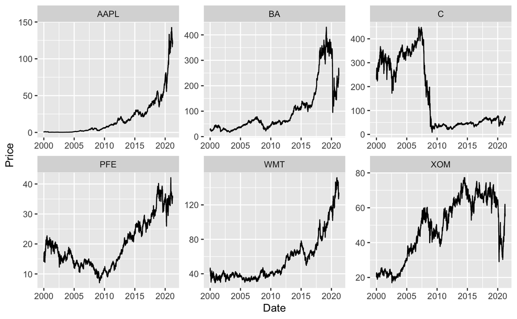

This seems alright, though Citigroup suffered massively in the subprime crisis.

Before we move towards the factors, we transform (via mutate) the daily prices into **monthly returns**. Returns are indeed the raw material in portfolio management. In the code, we resort to a lot of **piping** using the pipe operator **%>%**.

[output not shown]

[output cut: 245 more lines]

We now turn to the importation of **factor data**. It’s extracted from the database maintained by **Kenneth French**: http://mba.tuck.dartmouth.edu/pages/faculty/ken.french/data_library.html

```r
temp <- tempfile()
link <- "http://mba.tuck.dartmouth.edu/pages/faculty/ken.french/ftp/F-F_Research_Data_5_Factors_2x3_CSV.zip"
download.file(link, temp, quiet = TRUE)         # Download!
nb_factors <- 5                                 # Number of factors
FF_factors <- read_csv(unz(temp, "F-F_Research_Data_5_Factors_2x3.CSV"),   # The file name
                    skip = 3) %>%               # Check the number of lines to be skipped (could be 2!)
                    rename(Date = X1, MKT_RF = `Mkt-RF`) %>% # Change name of the first column
                    mutate_at(vars(-Date), as.numeric) %>%                 # Convert to number
                    mutate(Date = ymd(parse_date_time(Date, "%Y%m"))) %>%  # Date in right format
                    mutate(Date = rollback(Date + months(1)))              # End of month date
FF_factors <- FF_factors %>% mutate(MKT_RF = MKT_RF / 100,                 # Scaling returns
                                SMB = SMB / 100,
                                HML = HML / 100,
                                RMW = RMW / 100,
                                CMA = CMA / 100,
                                RF = RF / 100) %>%       # That's the risk-free rate
                        filter(Date >= min_date)         # Finally, we keep the recent points
head(FF_factors)                                         # And we have a look!
```

| Date | MKT_RF | SMB | HML | RMW | CMA | RF |
| --- | --- | --- | --- | --- | --- | --- |
| 2000-01-31 | -0.0474 | 0.0438 | -0.0175 | -0.0607 | 0.0473 | 0.0041 |
| 2000-02-29 | 0.0245 | 0.1808 | -0.0894 | -0.1848 | -0.0051 | 0.0043 |
| 2000-03-31 | 0.0520 | -0.1489 | 0.0766 | 0.1153 | -0.0105 | 0.0047 |
| 2000-04-30 | -0.0640 | -0.0525 | 0.0741 | 0.0766 | 0.0527 | 0.0046 |
| 2000-05-31 | -0.0442 | -0.0411 | 0.0501 | 0.0436 | 0.0074 | 0.0050 |
| 2000-06-30 | 0.0464 | 0.0989 | -0.0822 | -0.0805 | -0.0307 | 0.0040 |

Finally, we merge the two sources of data into one single variable.

```r
data <- left_join(returns, FF_factors, by = "Date")
# left_join() is an incredible function that merges two sets through one common column
head(data) # See the outcome!
```

| Date | AAPL | BA | C | PFE | WMT | XOM | MKT_RF | SMB | HML | RMW | CMA | RF |
| --- | --- | --- | --- | --- | --- | --- | --- | --- | --- | --- | --- | --- |
| 2000-02-29 | 0.10482082 | -0.16709992 | -0.08958280 | -0.11001066 | -0.109588524 | -0.086158267 | 0.0245 | 0.1808 | -0.0894 | -0.1848 | -0.0051 | 0.0043 |
| 2000-03-31 | 0.18484219 | 0.02368894 | 0.15700493 | 0.13813271 | 0.160431720 | 0.035684777 | 0.0520 | -0.1489 | 0.0766 | 0.1153 | -0.0105 | 0.0047 |
| 2000-04-30 | -0.08651699 | 0.04958672 | -0.01208483 | 0.15213672 | -0.019911867 | -0.004006476 | -0.0640 | -0.0525 | 0.0741 | 0.0766 | 0.0527 | 0.0046 |
| 2000-05-31 | -0.32292144 | -0.01213803 | 0.05402526 | 0.05844545 | 0.040632279 | 0.078225891 | -0.0442 | -0.0411 | 0.0501 | 0.0436 | 0.0074 | 0.0050 |
| 2000-06-30 | 0.24702371 | 0.07039950 | -0.03115563 | 0.07865162 | 0.001092284 | -0.057763831 | 0.0464 | 0.0989 | -0.0822 | -0.0805 | -0.0307 | 0.0040 |
| 2000-07-31 | -0.02983344 | 0.16741405 | 0.17012450 | -0.09635439 | -0.041214769 | 0.021496471 | -0.0251 | -0.0103 | 0.0840 | 0.0628 | 0.0299 | 0.0048 |

With our full dataset at hand, we are ready to begin the analysis.

# 2 Fama-Macbeth regressions

## 2.1 Principle

The **Fama-Macbeth regressions** can be used to assess the premium associated to factors. They are performed in two steps.

1. First, all assets are regressed against the chosen factors (which gives the **factor loadings**, i.e., the estimated coefficients in the regression).
2. Then, **for each date**, the (cross-sectional) returns of the assets are regressed against the loadings obtained in the first step.
- This yields time-series of premia, which can then be averaged into a proxy for the risk premium associated with each factor.

## 2.2 First pass

A natural way to proceed would be to resort to a for() loop to perform the regressions iteratively. We take another route and instead make us of the ‘**apply**’ family of functions. We use a procedure that creates all models via their character syntax in R. And finally, we gather the results in the ‘betas’ variable.

```r
models <- lapply(paste(tickers, ' ~  MKT_RF + SMB + HML + RMW + CMA'),    # Specification of models
                 function(f){ lm(as.formula(f), data = data) %>%          # Calling lm(.)
                         summary() %>%                                    # Gathering the output
                         "$"(coef) %>%                                    # Keeping only the coefs
                         data.frame() %>%                                 # Convert to dataframe
                         select(Estimate)}                                # Keep the coefficients
                 )

betas <- matrix(unlist(models), ncol = nb_factors + 1, byrow = T) %>%     # Extracting the betas
    data.frame(row.names = tickers)                                       # Formatting: row names
colnames(betas) <- c("Constant", "MKT_RF", "SMB", "HML", "RMW", "CMA")    # Formatting: col names
betas                                                                     # Showing the values
```

|  | Constant | MKT_RF | SMB | HML | RMW | CMA |
| --- | --- | --- | --- | --- | --- | --- |
| AAPL | 2.122008e-02 | 1.2772555 | 0.303015554 | -0.59937844 | 0.3576073 | -1.25829518 |
| BA | 3.422288e-03 | 1.1990284 | 0.003344281 | 0.58420213 | 0.3331527 | 0.02485047 |
| C | -5.027669e-04 | 1.5415699 | -0.625113974 | 2.17618914 | -1.0523092 | -1.14987029 |
| PFE | -9.586528e-05 | 0.7664967 | -0.466589785 | 0.02707460 | 0.1039557 | 0.50040923 |
| WMT | 2.715405e-03 | 0.5243044 | -0.372264009 | -0.09387261 | 0.3966904 | 0.16399673 |
| XOM | -2.125261e-03 | 0.8115892 | 0.093254135 | 0.21896471 | 0.4635543 | 0.19444577 |

The **market beta** is the second column. When there are no other factors, a beta above 1 (*resp. below 1*) means that the stock is more volatile than the market (*resp. less volatile*). The two stocks with high market betas also load heavily (and negatively on CMA). Citigroup also has a strong positive exposure to HML.

## 2.3 Second pass

We then turn to the second step of the procedure. This time, we regress asset returns against the betas, one date at a time. We start by formatting the data.

```r
loadings <- betas %>%       # Start from loadings
    select(-Constant) %>%   # Keep only the loadings
    data.frame()            # Convert to dataframe
ret <- returns %>%                              # Start from returns
    select(-Date) %>%                           # Keep the returns only
    data.frame(row.names = returns$Date) %>%    # Set row names
    t()                                         # Transpose

FM_data <- cbind(loadings, ret)                 # Aggregate both
FM_data[,1:8]                                   # A short look at the first 8 columns
```

|  | MKT_RF | SMB | HML | RMW | CMA | 2000-02-29 | 2000-03-31 | 2000-04-30 |
| --- | --- | --- | --- | --- | --- | --- | --- | --- |
| AAPL | 1.2772555 | 0.303015554 | -0.59937844 | 0.3576073 | -1.25829518 | 0.10482082 | 0.18484219 | -0.086516994 |
| BA | 1.1990284 | 0.003344281 | 0.58420213 | 0.3331527 | 0.02485047 | -0.16709992 | 0.02368894 | 0.049586716 |
| C | 1.5415699 | -0.625113974 | 2.17618914 | -1.0523092 | -1.14987029 | -0.08958280 | 0.15700493 | -0.012084826 |
| PFE | 0.7664967 | -0.466589785 | 0.02707460 | 0.1039557 | 0.50040923 | -0.11001066 | 0.13813271 | 0.152136717 |
| WMT | 0.5243044 | -0.372264009 | -0.09387261 | 0.3966904 | 0.16399673 | -0.10958852 | 0.16043172 | -0.019911867 |
| XOM | 0.8115892 | 0.093254135 | 0.21896471 | 0.4635543 | 0.19444577 | -0.08615827 | 0.03568478 | -0.004006476 |

This will be the inputs of the second stage of regressions: for each stock, we have both the returns and the associated loading values.

```r
models <- lapply(paste("`", returns$Date, "`", ' ~  MKT_RF + SMB + HML + RMW + CMA', sep = ""),
                 function(f){ lm(as.formula(f), data = FM_data) %>%       # Calling lm(.)
                         summary() %>%                                    # Gathering the output
                         "$"(coef) %>%                                    # Keeping only the coefs
                         data.frame() %>%                                 # Convert to dataframe
                         select(Estimate)}                                # Keep only the coefficients
                 )
gammas <- matrix(unlist(models), ncol = nb_factors + 1, byrow = T) %>%    # Switch to dataframe
    data.frame(row.names = returns$Date)                                  # & set row names
colnames(gammas) <- c("Constant", "MKT_RF", "SMB", "HML", "RMW", "CMA")   # Set col names
gammas                                                                    # Show the output
```

|  | Constant | MKT_RF | SMB | HML | RMW | CMA |
| --- | --- | --- | --- | --- | --- | --- |
| 2000-02-29 | 0.2016782432 | -0.156636097 | 0.2802634226 | -0.1243466678 | -0.3244169424 | -0.0474974986 |
| 2000-03-31 | 0.1498230971 | -0.048375264 | -0.1688877943 | -0.0834820780 | -0.0495606135 | -0.0919245127 |
| 2000-04-30 | -0.1520907936 | 0.261054356 | -0.0460553389 | -0.1051135498 | -0.1646933476 | 0.2050481457 |
| 2000-05-31 | 0.3391032547 | -0.316735488 | 0.1980178470 | 0.1397004012 | -0.1715331029 | 0.1370108770 |
| 2000-06-30 | -0.4285782770 | 0.468217107 | -0.3122595849 | -0.1807978583 | 0.1337370666 | -0.0127131676 |
| 2000-07-31 | -0.4098470083 | 0.247972189 | -0.2256745057 | 0.2150362239 | 0.4709117358 | -0.0732413264 |
| 2000-08-31 | -0.1465593017 | 0.313586496 | 0.2450631202 | -0.0968413505 | -0.2212980682 | 0.0857295108 |
| 2000-09-30 | -0.4240984920 | 0.189883675 | -0.2781890735 | 0.3496729457 | 0.5687763967 | 0.2426970434 |
| 2000-10-31 | -0.2011082152 | 0.086419196 | -0.0578560132 | 0.1426153786 | 0.1904772519 | 0.0911288093 |
| 2000-11-30 | -0.1732003763 | -0.037442215 | -0.4733692088 | 0.1357795989 | 0.4899668899 | -0.0906643345 |

[output cut: 244 more lines]

Note that the estimates are not going to be very reliable because the number of observations (number of stocks, i.e., 6) is barely larger than the number of variables (number of factors, 5). Accuracy would require a much larger number of assets (hundreds, or, preferably, thousands).

```r
gammas %>% colMeans()                                                     # Means (over all periods)
```

```
    Constant       MKT_RF          SMB          HML          RMW          CMA
-0.019539136  0.024422040 -0.015659154 -0.005824618  0.020278953 -0.007523978
```

```r
apply(gammas, 2, t.test) %>% unlist %>%                                   # t-stats
    matrix(ncol = ncol(gammas), dimnames = list(c(), colnames(betas))) %>%
    data.frame() %>% slice(1) # Take only the first line of the test
```

| Constant | MKT_RF | SMB | HML | RMW | CMA |
| --- | --- | --- | --- | --- | --- |
| -1.08432822456203 | 1.80236780096519 | -0.923379351760857 | -1.07509980264524 | 1.10838490061904 | -1.38105775443921 |

## 2.4 Graphical interpretation

Let’s nonetheless visually assess the stability of premia across time.

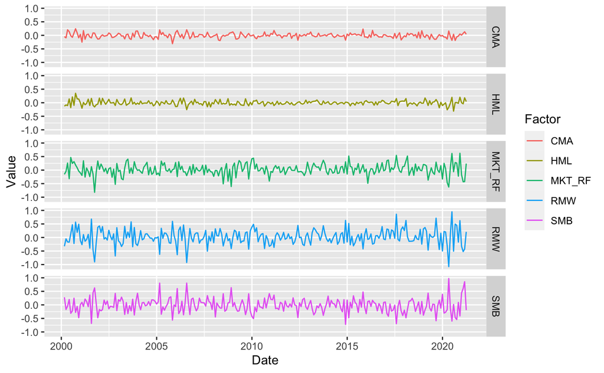

```r
gammas %>%                                          # Start from gamma (estimates)
    select(-Constant) %>%                           # Take out the constant
    rownames_to_column("Date") %>%                  # Convert row names to the first column => dates
    mutate(Date = as.Date(Date)) %>%                # Convert first date column to true date format
    gather(key = Factor, value = Value, -Date) %>%  # Put in column format for ggplot
    ggplot(aes(x = Date, y = Value, color = Factor)) + geom_line() + facet_grid(Factor~.) # Plot
```

**CMA** and **HML** appears more stable, while RMW and SMB are more volatile.  
Finally, what are the annual average of these series? We build a simple pivot-table below.

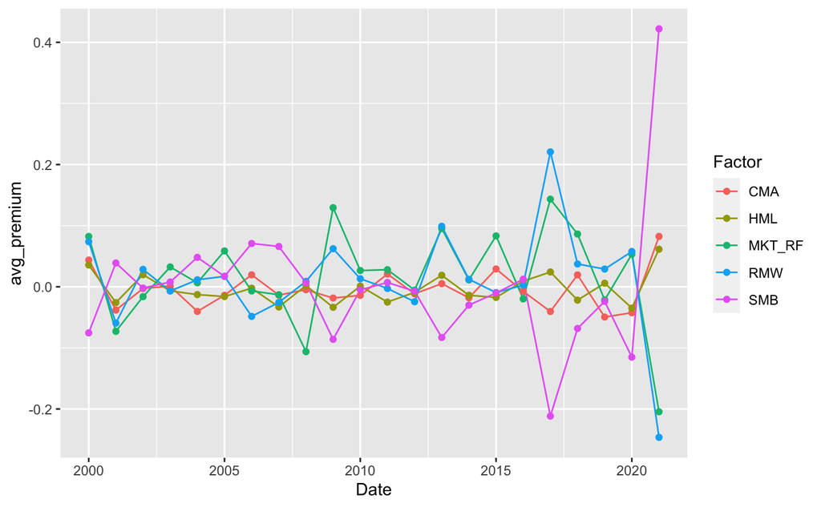

```r
gammas %>%                                          # To create a pivot table, start with the gammas
    select(-Constant) %>%                           # Take out the constant
    rownames_to_column("Date") %>%                  # Convert row names to the first column
    mutate(Date = year(as.Date(Date))) %>%          # Convert this new first column to year
    gather(key = Factor, value = Value, -Date) %>%  # Put into column format
    group_by(Date, Factor) %>%                      # Prepare pivot-table
    summarise(avg_premium = mean(Value)) %>%        # Pivot table!
    ggplot(aes(x = Date, y = avg_premium, color = Factor)) + geom_line() + geom_point() # Plot
```

# 3 Factor competition

Below, we regress each factor against all its ‘*competitors*’. If the alpha (coefficient of the constant/Integer vector) in the regression is not significantly different from zero, it means that the factor is somewhat **redundant** because it can be ‘explained’ by exposures to other factors. If not, the factor cannot be explained by the other factors and is thus adding value to the analysis.

We can thus work simply with the **Fama-French** factors with no external data.

```r
factors <- c("MKT_RF", "SMB", "HML", "RMW", "CMA")
models <- lapply(paste(factors, ' ~  MKT_RF + SMB + HML + RMW + CMA-',factors),
 function(f){ lm(as.formula(f), data = FF_factors) %>%              # Calling lm(.)
                         summary() %>%                              # Gathering the output
                         "$"(coef) %>%                              # Keeping only the coefs
                         data.frame() %>%                           # Convert to dataframe
                         filter(rownames(.) == "(Intercept)") %>%   # Keep only the Intercept
                         select(Estimate,`Pr...t..`)}               # Keep the coefficient & p-value
                 )
alphas <- matrix(unlist(models), ncol = 2, byrow = T) %>% # Switch from list to dataframe
    data.frame(row.names = factors)                       # Set row names
colnames(alphas) <- c("coef", "p-value")                  # Set col names
alphas                                                    # Show
```

|  | coef | p-value |
| --- | --- | --- |
| MKT_RF | 0.008762479 | 6.386772e-04 |
| SMB | 0.004626878 | 7.744603e-03 |
| HML | -0.004277488 | 6.806581e-03 |
| RMW | 0.005686956 | 3.911178e-05 |
| CMA | 0.002760002 | 9.514011e-03 |

# 4 Exercises

1. Perform Fama-MacBeth regressions using a few more stocks (say, ten: find some more on Yahoo) and see if that changes the results.
2. Try factor competition on another dataset from Ken French’s library (e.g., add the momentum factor).